# Ospree phylogenetic analyses

I. Morales-Castilla

11/18/2019

# 1. Introduction

## 1.1 Why care about phylogenies?

When we analyze interespecific data in ecology—i.e. data recorded across multiple species—we need to account for phylogenetic autocorrelation, or the fact that species are not independent from each other. This is, phylogenetically close species will tend to be more similar than expected by chance.

Phylogenetic multilevel models account for species non-independence by modelling residual variation as a function of the phylogenetic variances-covariances among species. This approach is the hierarchical version of PGLS (Freckleton et al. 2002) and contrasts to alternative multilevel models where variation due to species differences would be modelled as a grouping factor to estimate varying intercepts (and possibly also varying slopes) over species.

## 1.2 Housekeeping, package loading, etc.

```r
## to start - housekeeping
rm(list=ls())
options(stringsAsFactors=FALSE)



## load packages
library(shinystan)
library(caper)
library(brms)
library(pez)
library(rstan)
library(phytools)
library(MCMCglmm)
library(knitr)
```

#### get ospree data and phylogeny

# 2. Running, saving, loading PGLMM models

## 2.1 Loading previously saved PGLMM models

```r
library(knitr)

PGLMM_results_ospree <- read.csv("output/PGLMM_results_ospree.csv")
PGLMM_results_ospree[is.na.data.frame(PGLMM_results_ospree)] = ""

kable(PGLMM_results_ospree)
```

| Model | fixed.effect | Posterior.estimate | low.95..CI | up.95..CI | eff.samp | pMCMC | H2_2.5 | H2_50 | H2_97.5 |
| --- | --- | --- | --- | --- | --- | --- | --- | --- | --- |
| Full | Intercept | 30.473 | -23.965 | 95.426 | 1000.000 | 0.278 | 0.869 | 0.905 | 0.934 |
|  | force | -6.516 | -7.201 | -5.952 | 1000.000 | 0.001 |  |  |  |
|  | chill | -4.197 | -4.728 | -3.613 | 1000.000 | 0.001 |  |  |  |
|  | photo | -1.769 | -2.320 | -1.091 | 900.973 | 0.001 |  |  |  |
| Forcing | Intercept | 34.331 | -31.651 | 83.062 | 1000.000 | 0.232 | 0.868 | 0.905 | 0.932 |
|  | force | -6.940 | -7.540 | -6.307 | 1134.064 | 0.001 |  |  |  |
| Chilling | Intercept | 32.374 | -19.862 | 95.732 | 1000.000 | 0.296 | 0.856 | 0.899 | 0.928 |
|  | chill | -4.260 | -4.809 | -3.608 | 1148.251 | 0.001 |  |  |  |
| Photo | Intercept | 33.653 | -29.530 | 93.414 | 1582.738 | 0.278 | 0.862 | 0.904 | 0.933 |
|  | photo | -2.762 | -3.418 | -2.096 | 1000.000 | 0.001 |  |  |  |

According to PGLMM BB responses to all three cues are strongly phylogenetically structured/inherited. in other words ~90% of the variance is explained by the (phylogenetically structured) differences across species. Phylogenetically close species are more likely to show similar responses to each of the cues (a little more so for forcing).

A comparison of PGLMM results against our previous results in the BB ms. reveal a shift in importance between chilling and forcing. Forcing shows a stronger effect size than chilling, at least according to PGLMM.

# 3. Running, saving, loading BRMS models

Let’s explore the results for different specifications of BRMS models.

## 3.1. Simple, non-phylogenetic model

The model specification:

$$Budbreak = \alpha_{species} + \beta_{1}forcing
+ \beta_{2}chilling + \beta_{3}photo + \varepsilon$$

```r
#### BRMS repeated measures, random on slopes MODEL ####
#model commented out to avoid running
#model_NOphylo.FULL <- brm(
#  resp ~ withinsp.forcemeans + withinsp.chillmeans + withinsp.photomeans + ## fixed
#    (1|species),  ## rnd effs
#  data = bb.stan,
#  family = gaussian(), cov_ranef = list(phylo = A),
#  prior = c(
#    prior(normal(0, 20), "b"),
#    prior(normal(0, 50), "Intercept"),
#    prior(student_t(3, 0, 20), "sd"),
#    prior(student_t(3, 0, 20), "sigma")
#  )
#  ,sample_prior = TRUE, chains = 2, cores = 4,
#  iter = 1000, warmup = 500
#)

#load model result
#save(model_NOphylo.FULL,file = "output/full_nophylomod.RData")
load("output/full_nophylomod.RData")
#model_NOphylo.FULL

library(brms)

#inspect results
NOphyloeffs<-rbind(
  summary(model_NOphylo.FULL)$fixed,
  summary(model_NOphylo.FULL)$random$species,
  summary(model_NOphylo.FULL)$spec_pars
)
NOphyloeffs[,1:5] = round(NOphyloeffs[,1:5],3)
kable(NOphyloeffs)
```

|  | Estimate | Est.Error | l-95% CI | u-95% CI | Rhat | Bulk_ESS | Tail_ESS |
| --- | --- | --- | --- | --- | --- | --- | --- |
| Intercept | 31.853 | 2.188 | 27.316 | 36.045 | 1.009 | 289 | 550 |
| withinsp.forcemeans | -6.485 | 0.331 | -7.136 | -5.829 | 1.001 | 6571 | 3937 |
| withinsp.chillmeans | -4.157 | 0.287 | -4.725 | -3.594 | 1.001 | 7220 | 4839 |
| withinsp.photomeans | -1.841 | 0.330 | -2.484 | -1.198 | 1.000 | 8097 | 4347 |
| sd(Intercept) | 17.573 | 1.635 | 14.588 | 21.162 | 1.008 | 629 | 999 |
| sigma | 15.558 | 0.186 | 15.202 | 15.919 | 1.000 | 7775 | 4348 |

```r
#plot(marginal_effects(model_phylo.PGLS), points = TRUE, ask=T)
#pp_check(model_phylo.PGLS)


## the phylogenetic signal
hyp.NOphylo <- paste(
  "(sd_species__Intercept^2) /",
  "(sd_species__Intercept^2
  + sigma^2) = 0.0"
)
(lambda.NOphylo <- hypothesis(model_NOphylo.FULL, hyp.NOphylo, class = NULL))
```

```
## Hypothesis Tests for class :
##                 Hypothesis Estimate Est.Error CI.Lower CI.Upper Evid.Ratio
## 1 ((sd_species__Int... = 0     0.56      0.05     0.47     0.65          0
##   Post.Prob Star
## 1         0    *
## ---
## 'CI': 90%-CI for one-sided and 95%-CI for two-sided hypotheses.
## '*': For one-sided hypotheses, the posterior probability exceeds 95%;
## for two-sided hypotheses, the value tested against lies outside the 95%-CI.
## Posterior probabilities of point hypotheses assume equal prior probabilities.
```

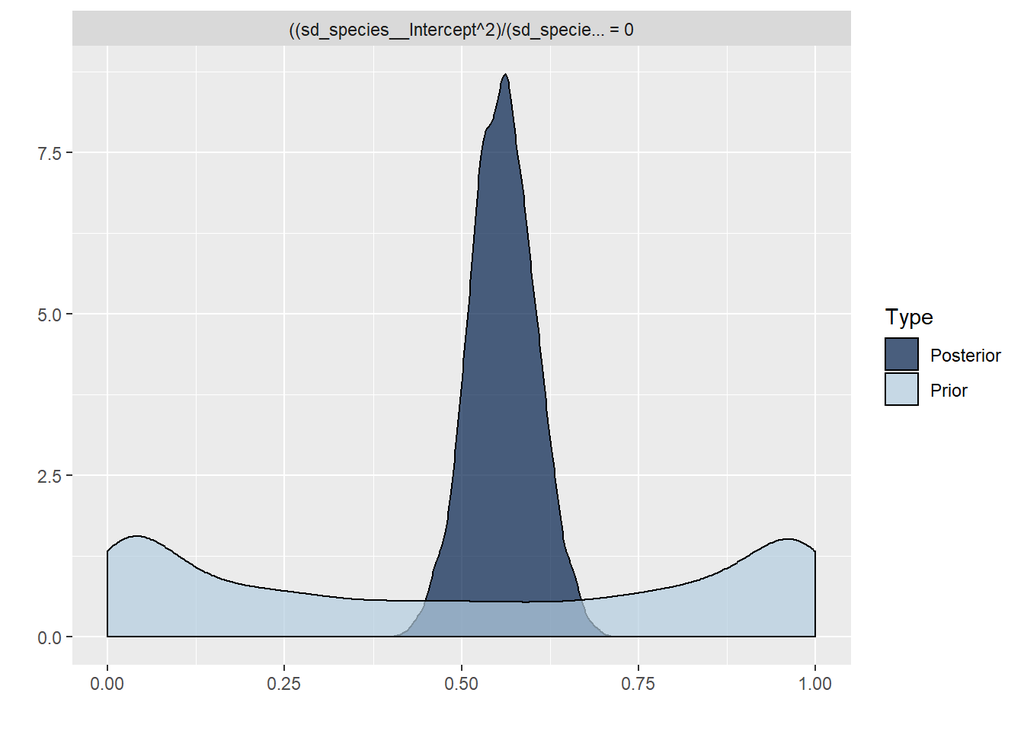

```r
plot(lambda.NOphylo)
```

## 3.2. Simple, phylogenetic model, phylogeny on intercepts

The model specification (following BRMS):

$$Budbreak = \alpha_{phylo,species} + \beta_{1}forcing
+ \beta_{2}chilling + \beta_{3}photo + \varepsilon$$

This is the simple multilevel model for repeated measures, where intraspecific variation for the cues is considered. Grouping factors on the intercept consider the phylogenetic structure ($\alpha_{phylo}$) and other inter-specific variation independent from the phylogeny ($\alpha_{species}$).

This model makes a bit more sense than the previous one, but we still lack information of interest. While this model informs us about the convenience of accounting for phylogenetic non-independence, and gives us a measure of how much the residual variation is phylogenetically structured, we still lack specific sensitivities to each cue (we’d need grouping on the slopes too).

```r
#### PGLS repeated MODEL ####
### ## ad mean of predictors across species and within species

#bb.stan$forcemeans <-
#  with(bb.stan, sapply(split(force.z, phylo), mean)[phylo])

#bb.stan$withinsp.forcemeans <-
#  bb.stan$force.z - bb.stan$forcemeans

#bb.stan$chillmeans <-
#  with(bb.stan, sapply(split(chill.z, phylo), mean)[phylo])

#bb.stan$withinsp.chillmeans <-
#  bb.stan$chill.z - bb.stan$chillmeans

#bb.stan$photomeans <-
#  with(bb.stan, sapply(split(photo.z, phylo), mean)[phylo])

#bb.stan$withinsp.photomeans <-
#  bb.stan$photo.z - bb.stan$photomeans

#model commented out to avoid running
#model_phylo.PGLS <- brm(
#  resp ~ withinsp.forcemeans + withinsp.chillmeans +
#    withinsp.photomeans +      ## fixed effs
#    (1 |phylo) + (1|species),  ## rnd effs
#  data = bb.stan,
#  family = gaussian(), cov_ranef = list(phylo = A),
#  prior = c(
#    prior(normal(0, 20), "b"),
#    prior(normal(0, 50), "Intercept"),
#    prior(student_t(3, 0, 20), "sd"),
#    prior(student_t(3, 0, 20), "sigma")
#  )
# ,sample_prior = TRUE, chains = 2, cores = 4,
#  iter = 2000, warmup = 500
#)

#load model result
load("output/pgls_phylomod_onlyphy.RData")
#model_phylo.PGLS


#inspect results
PGLSeffs<-rbind(
  summary(model_phylo.PGLS)$fixed,
  summary(model_phylo.PGLS)$random$phylo,
  summary(model_phylo.PGLS)$random$species,
  summary(model_phylo.PGLS)$spec_pars
)
PGLSeffs[,1:5] = round(PGLSeffs[,1:5],3)
kable(PGLSeffs)
```

|  | Estimate | Est.Error | l-95% CI | u-95% CI | Rhat | Bulk_ESS | Tail_ESS |
| --- | --- | --- | --- | --- | --- | --- | --- |
| Intercept | 31.156 | 19.201 | -7.484 | 69.864 | 1.002 | 2602 | 2212 |
| within_species | -6.515 | 0.332 | -7.166 | -5.887 | 1.000 | 7981 | 2229 |
| withinsp.chillmeans | -4.030 | 0.289 | -4.580 | -3.457 | 1.000 | 6487 | 2102 |
| withinsp.photomeans | -1.689 | 0.320 | -2.316 | -1.075 | 1.000 | 7275 | 1834 |
| sd(Intercept) | 31.844 | 5.940 | 22.637 | 45.662 | 1.003 | 719 | 824 |
| sd(Intercept) | 12.462 | 2.192 | 8.186 | 16.723 | 1.003 | 723 | 834 |
| sigma | 15.220 | 0.183 | 14.870 | 15.568 | 1.001 | 7256 | 1993 |

```r
#plot(marginal_effects(model_phylo.PGLS), points = TRUE, ask=T)
#pp_check(model_phylo.PGLS)


## the phylogenetic signal
hyp.pgls <- paste(
  "(sd_phylo__Intercept^2) /",
  "(sd_phylo__Intercept^2
  + sd_species__Intercept^2
  + sigma^2) = 0.0"
)
(lambda.pgls <- hypothesis(model_phylo.PGLS, hyp.pgls, class = NULL))
```

```
## Hypothesis Tests for class :
##                 Hypothesis Estimate Est.Error CI.Lower CI.Upper Evid.Ratio
## 1 ((sd_phylo__Inter... = 0     0.71      0.08     0.54     0.87          0
##   Post.Prob Star
## 1         0    *
## ---
## 'CI': 90%-CI for one-sided and 95%-CI for two-sided hypotheses.
## '*': For one-sided hypotheses, the posterior probability exceeds 95%;
## for two-sided hypotheses, the value tested against lies outside the 95%-CI.
## Posterior probabilities of point hypotheses assume equal prior probabilities.
```

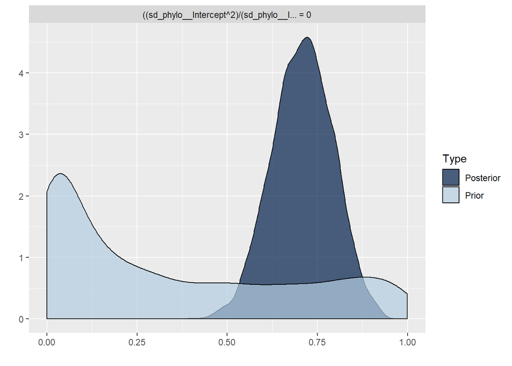

```r
plot(lambda.pgls)
```

The results are very similar to PGLMM results. However, $H^{2}$ seems greater in PGLMM than in BRMS.

A more complete version of the BRMS model accounts for species differences in slopes:
$$Budbreak = \alpha_{phylo,species} + \beta_{1,phylo}forcing
+ \beta_{2,phylo}chilling + \beta_{3,phylo}photo + \varepsilon$$

This is the simple multilevel model for repeated measures, where intraspecific variation for the cues is considered. Grouping factors on the intercept consider the phylogenetic structure ($\alpha_{phylo}$) and other inter-specific variation independent from the phylogeny ($\alpha_{species}$).

```r
#### BRMS repeated measures, random on slopes MODEL ####
#model commented out to avoid running
#model_phylo.FULL <- brm(
#  resp ~ withinsp.forcemeans + withinsp.chillmeans + withinsp.photomeans + ## fixed
#    (1 + within_species + withinsp.chillmeans + withinsp.photomeans | phylo) +
#    (1|species),  ## rnd effs
#  data = bb.stan,
#  family = gaussian(), cov_ranef = list(phylo = A),
#  prior = c(
#    prior(normal(0, 20), "b"),
#    prior(normal(0, 50), "Intercept"),
#    prior(student_t(3, 0, 20), "sd"),
#    prior(student_t(3, 0, 20), "sigma")
#  )
#  ,sample_prior = TRUE, chains = 2, cores = 4,
#  iter = 2000, warmup = 500
#)

#load model result
load("output/full_phylomod_onlyphy.RData")
#model_phylo.PGLS


#inspect results
FULLeffs<-rbind(
  summary(model_phylo.FULL)$fixed,
  summary(model_phylo.FULL)$random$phylo,
  summary(model_phylo.FULL)$random$species,
  summary(model_phylo.FULL)$spec_pars
)
FULLeffs[,1:5] = round(FULLeffs[,1:5],3)

kable(FULLeffs[c(1:8,15:16),])
```

|  | Estimate | Est.Error | l-95% CI | u-95% CI | Rhat | Bulk_ESS | Tail_ESS |
| --- | --- | --- | --- | --- | --- | --- | --- |
| Intercept | 28.103 | 17.983 | -7.516 | 63.959 | 1.000 | 1983 | 2120 |
| within_species | -5.598 | 7.640 | -20.683 | 9.136 | 1.002 | 2175 | 2147 |
| withinsp.chillmeans | -2.887 | 7.594 | -18.020 | 11.829 | 1.001 | 1978 | 2014 |
| withinsp.photomeans | -1.839 | 5.488 | -12.600 | 9.106 | 1.001 | 2321 | 2043 |
| sd(Intercept) | 31.580 | 5.977 | 20.914 | 44.474 | 1.000 | 1081 | 1899 |
| sd(within_species) | 13.951 | 1.938 | 10.510 | 17.980 | 1.001 | 1901 | 2152 |
| sd(withinsp.chillmeans) | 13.921 | 2.595 | 9.361 | 19.638 | 1.001 | 1709 | 2318 |
| sd(withinsp.photomeans) | 10.006 | 2.147 | 6.344 | 14.804 | 1.002 | 2098 | 2628 |
| sd(Intercept) | 12.258 | 2.072 | 8.293 | 16.509 | 1.001 | 1227 | 1561 |
| sigma | 13.653 | 0.166 | 13.338 | 13.983 | 1.001 | 4942 | 1909 |

```r
#plot(marginal_effects(model_phylo.PGLS), points = TRUE, ask=T)
#pp_check(model_phylo.PGLS)


## the phylogenetic signal
hyp.full <- paste(
  "(sd_phylo__Intercept^2 +
    sd_phylo__within_species^2 +
    sd_phylo__withinsp.chillmeans^2 +
    sd_phylo__withinsp.photomeans^2) /",
  "(sd_phylo__Intercept^2 +
    sd_phylo__within_species^2 +
    sd_phylo__withinsp.chillmeans^2 +
    sd_phylo__withinsp.photomeans^2
  + sd_species__Intercept^2
  + sigma^2) = 0.0"
)
(lambda.FULL <- hypothesis(model_phylo.FULL, hyp.full, class = NULL))
```

```
## Hypothesis Tests for class :
##                 Hypothesis Estimate Est.Error CI.Lower CI.Upper Evid.Ratio
## 1 ((sd_phylo__Inter... = 0     0.81      0.05      0.7      0.9          0
##   Post.Prob Star
## 1         0    *
## ---
## 'CI': 90%-CI for one-sided and 95%-CI for two-sided hypotheses.
## '*': For one-sided hypotheses, the posterior probability exceeds 95%;
## for two-sided hypotheses, the value tested against lies outside the 95%-CI.
## Posterior probabilities of point hypotheses assume equal prior probabilities.
```

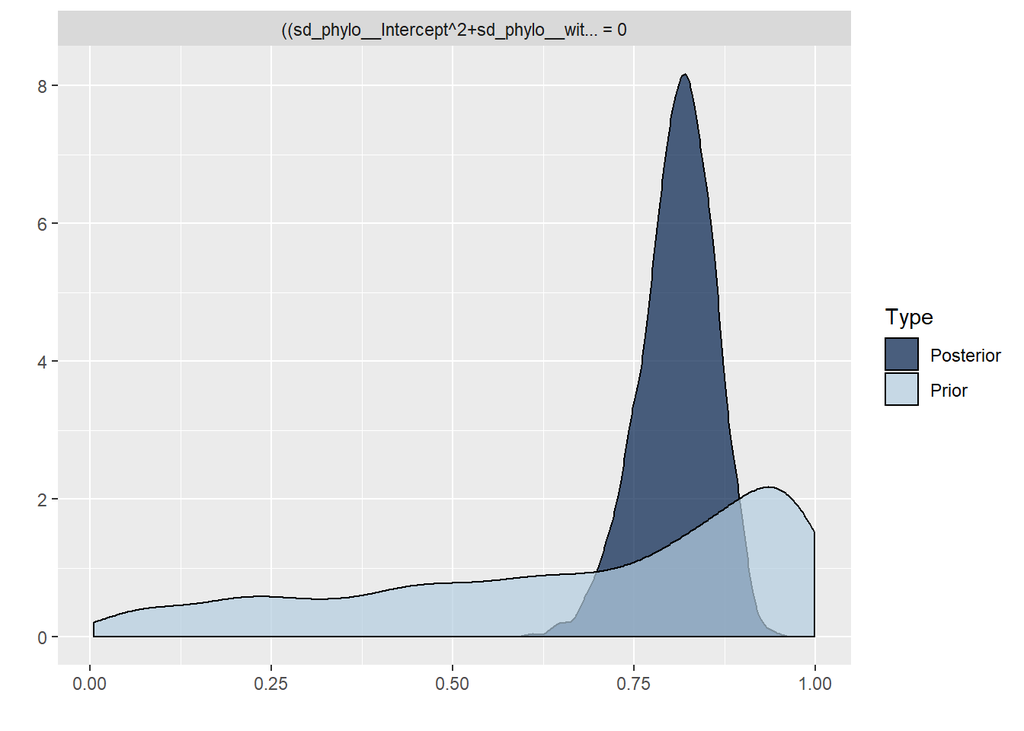

```r
plot(lambda.FULL)
```

Again, forcing is a stronger predictor than chilling, and $\lambda$ is high, and thus model residuals are strongly phylogenetically correlated.